# Class8 demo

Lei Song<sup>1</sup>

<sup>1</sup> Clark Unversity

2021-03-18

## Load packages

Within this vignette (or document), packages `here` is used to take care of the paths. `dplyr` is used to do data manipulation, and `readr` is used to read csv file.

In terms of data visualization, `kableExtra` is used to make tables, and `ggplot2` is used to make figures.

```r
# Load all packages in need
library(here)
library(dplyr)
library(readr)
library(ggplot2)
library(cowplot)
library(kableExtra)
```

## Combining

### Prepare dummy data

In order to show how `*_join` works, I created dummy data by splitting the data recommendation dataset into weather part and soil part. Then randomly select 80% from soil part to make it shorter than weather part.

```r
# Calculate the mean of all observations for each crop type
## Change to your own path
crop_rmd <- read_csv(here(
  file.path('docs/homeworks',
            'Crop_recommendation.csv'))) %>%
  group_by(label) %>%
  summarise_at(c('temperature', 'humidity', 'rainfall',
                 'N', 'P', 'K', 'ph'), mean)
# Split the table into two parts: weather and soil
crop_rmd_weather <- crop_rmd %>%
  select(label, temperature, humidity, rainfall)
crop_rmd_weather
```

```
## # A tibble: 22 x 4
##    label       temperature humidity rainfall
##    <chr>             <dbl>    <dbl>    <dbl>
##  1 apple              22.6     92.3    113.
##  2 banana             27.4     80.4    105.
##  3 blackgram          30.0     65.1     67.9
##  4 chickpea           18.9     16.9     80.1
##  5 coconut            27.4     94.8    176.
##  6 coffee             25.5     58.9    158.
##  7 cotton             24.0     79.8     80.4
##  8 grapes             23.8     81.9     69.6
##  9 jute               25.0     79.6    175.
## 10 kidneybeans        20.1     21.6    106.
## # … with 12 more rows
```

```r
set.seed(10)
crop_rmd_soil <- crop_rmd %>%
  select(label, N, P, K, ph) %>%
  sample_frac(0.8) %>%
  # add a dummy row for soybean
  rbind(data.frame(label = 'soybean',
                   N = 18.9, P = 78.4,
                   K = 45.3, ph = 6.45))
crop_rmd_soil
```

```
## # A tibble: 19 x 5
##    label           N     P     K    ph
##    <chr>       <dbl> <dbl> <dbl> <dbl>
##  1 lentil       18.8  68.4  19.4  6.93
##  2 jute         78.4  46.9  40.0  6.73
##  3 kidneybeans  20.8  67.5  20.0  5.75
##  4 muskmelon   100.   17.7  50.1  6.36
##  5 maize        77.8  48.4  19.8  6.25
##  6 grapes       23.2 133.  200.   6.03
##  7 coffee      101.   28.7  29.9  6.79
##  8 cotton      118.   46.2  19.6  6.91
##  9 blackgram    40.0  67.5  19.2  7.13
## 10 orange       19.6  16.6  10.0  7.02
## 11 pomegranate  18.9  18.8  40.2  6.43
## 12 mungbean     21.0  47.3  19.9  6.72
## 13 papaya       49.9  59.0  50.0  6.74
## 14 banana      100.   82.0  50.0  5.98
## 15 mango        20.1  27.2  29.9  5.77
## 16 coconut      22.0  16.9  30.6  5.98
## 17 pigeonpeas   20.7  67.7  20.3  5.79
## 18 mothbeans    21.4  48.0  20.2  6.83
## 19 soybean      18.9  78.4  45.3  6.45
```

### `*_join`

Then I take the dummy data that I created above to test how these `*_join` functions work and what are the differences between them.

```r
# Left join, keep all rows of data on left side.
crop_lj <- left_join(crop_rmd_weather, crop_rmd_soil,
                     by = 'label')
# Right join, keep all rows of data on right side.
crop_rj <- right_join(crop_rmd_weather, crop_rmd_soil,
                      by = 'label')
# What I will get if I do this?
crop_lj2 <- left_join(crop_rmd_soil, crop_rmd_weather,
                      by = 'label')

# Inner join, take the common part of data on left and right side.
crop_ij <- inner_join(crop_rmd_weather, crop_rmd_soil,
                      by = 'label')
# Full join, keep all rows of data on both left and right side.
crop_fj <- full_join(crop_rmd_weather, crop_rmd_soil,
                     by = 'label')
```

## Make tables

Then, using the data generated above, I create some tables using package `kableExtra`. You could find more details and examples [here](https://cran.r-project.org/web/packages/kableExtra/vignettes/awesome_table_in_html.html).

```r
crop_ij %>%
  kbl(caption = 'Mean of observations') %>%
  kable_paper(lightable_options = 'basic', # could be basic, striped, or hover
              html_font = 'helvetica', # could be any font installed on your machine.
              font_size = 12, # font size
              full_width = F, # full width or not
              position = "left", # center, left, right, or float-left and float-right
              fixed_thead = T) %>% # for a very long cross-pages table.
  column_spec(1, bold = T, background = 'pink') %>% # customize a column
  row_spec(which(crop_ij$temperature == max(crop_ij$temperature)),
           italic = T, color = 'red') # customize a row
```

Mean of observations

| label | temperature | humidity | rainfall | N | P | K | ph |
| --- | --- | --- | --- | --- | --- | --- | --- |
| banana | 27.37680 | 80.35812 | 104.62698 | 100.23 | 82.01 | 50.05 | 5.983893 |
| blackgram | 29.97334 | 65.11843 | 67.88415 | 40.02 | 67.47 | 19.24 | 7.133952 |
| coconut | 27.40989 | 94.84427 | 175.68665 | 21.98 | 16.93 | 30.59 | 5.976562 |
| coffee | 25.54048 | 58.86985 | 158.06629 | 101.20 | 28.74 | 29.94 | 6.790308 |
| cotton | 23.98896 | 79.84347 | 80.39804 | 117.77 | 46.24 | 19.56 | 6.912675 |
| grapes | 23.84958 | 81.87523 | 69.61183 | 23.18 | 132.53 | 200.11 | 6.025937 |
| jute | 24.95838 | 79.63986 | 174.79280 | 78.40 | 46.86 | 39.99 | 6.732778 |
| kidneybeans | 20.11508 | 21.60536 | 105.91978 | 20.75 | 67.54 | 20.05 | 5.749411 |
| lentil | 24.50905 | 64.80478 | 45.68045 | 18.77 | 68.36 | 19.41 | 6.927932 |
| maize | 22.38920 | 65.09225 | 84.76699 | 77.76 | 48.44 | 19.79 | 6.245190 |
| mango | 31.20877 | 50.15657 | 94.70452 | 20.07 | 27.18 | 29.92 | 5.766373 |
| mothbeans | 28.19492 | 53.16042 | 51.19849 | 21.44 | 48.01 | 20.23 | 6.831174 |
| mungbean | 28.52577 | 85.49997 | 48.40360 | 20.99 | 47.28 | 19.87 | 6.723957 |
| muskmelon | 28.66307 | 92.34280 | 24.68995 | 100.32 | 17.72 | 50.08 | 6.358805 |
| orange | 22.76573 | 92.17021 | 110.47497 | 19.58 | 16.55 | 10.01 | 7.016958 |
| papaya | 33.72386 | 92.40339 | 142.62784 | 49.88 | 59.05 | 50.04 | 6.741442 |
| pigeonpeas | 27.74176 | 48.06163 | 149.45756 | 20.73 | 67.73 | 20.29 | 5.794175 |
| pomegranate | 21.83784 | 90.12550 | 107.52844 | 18.87 | 18.75 | 40.21 | 6.429172 |

## Make figures

In this section, I will use the data generated above to make some figures using both base R and `ggplot2`.

### Base plot

#### Scatterplot

I make scatterplots to show the relationship between ph value, rainfall and humidity. Then fit a linear model to show their quantitative correlation. The figure below show a highly customized figure.

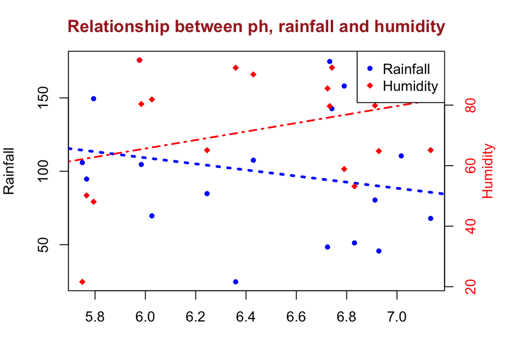

```r
# set the margin, c(bottom, left, top, right)
par(mar = c(3, 4, 3, 4))
# Make the main plot
plot(crop_ij$ph, crop_ij$rainfall, # set x and y
     pch = 20, col = 'blue', # set points style
     main = 'Relationship between ph, rainfall and humidity', # add main
     col.main = 'brown', # set main color
     xlab = 'ph', ylab = 'Rainfall') # set x and y axis

# Add a fit line
abline(lm(crop_ij$rainfall ~ crop_ij$ph),
       lty = 3, lwd = 3, col = 'blue')

# Add another scatterplot using points
## Reset plot window
plot.window(xlim = range(crop_ij$ph),
            ylim = range(crop_ij$humidity))

## Another syntax to use plot: with(dataset, plot(x, y))
with(crop_ij, points(ph, humidity,
                     pch = 18, col = 'red'))
# Add fit line
with(crop_ij, abline(lm(humidity ~ ph),
                     lty = 4, lwd = 2,
                     col = 'red'))

# Add another axis
axis(4, col.axis = "red")
## Add lab for this axis
mtext(side = 4, line = 2, "Humidity", col = 'red')

# Add legend
legend("topright", pch = c(20, 18),
       col = c("blue", "red"),
       legend = c("Rainfall", "Humidity"))
```

#### Histogram and boxplot

I make histogram and boxplot of temperature.

```r
# Re-read the full dataset
crop_rmd <- read_csv(here('docs/homeworks/Crop_recommendation.csv'))
```

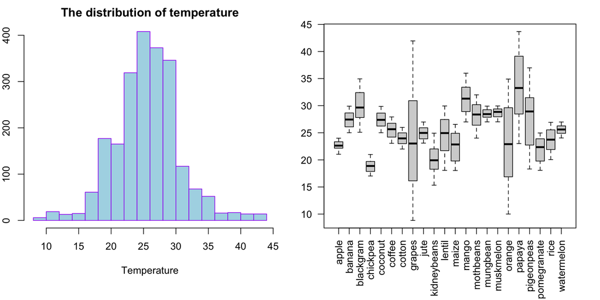

```r
# set the layer, c(row, col)
par(mfrow = c(1, 2), mar = c(6, 2, 2, 2))
hist(crop_rmd$temperature,
     col = 'lightblue', border = 'purple',
     main = 'The distribution of temperature',
     xlab = 'Temperature')
boxplot(temperature ~ label, crop_rmd,
        xlab = '',
        ylab = 'Temperature',
        las = 2)
```

### `ggplot2`

Using `ggplot2` to make figure deserve another full credit course. Here I just list some examples corresponding to the figures made by base plot above.

#### Scatterplot

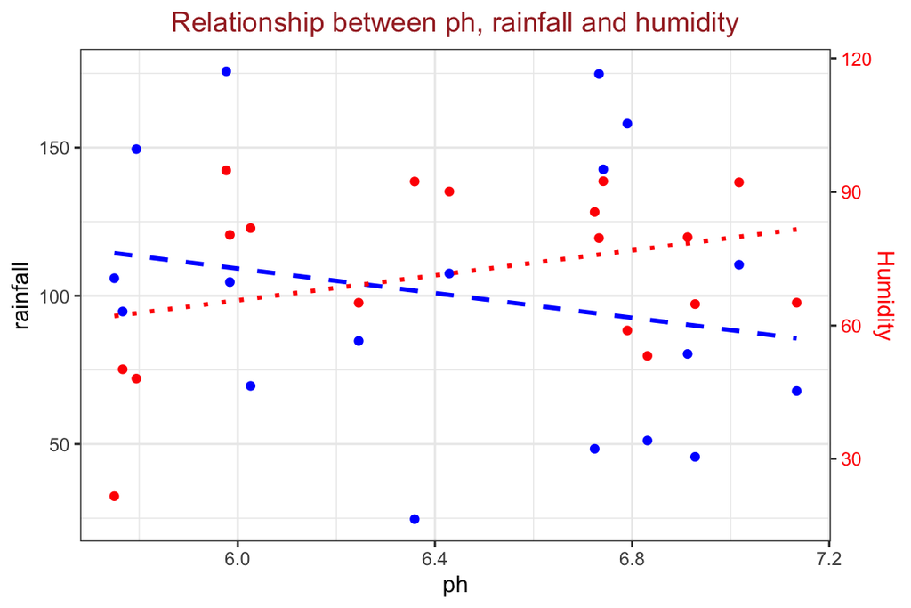

```r
ggplot(crop_ij) +
  geom_point(aes(x = ph, y = rainfall),
             color = 'blue') +
  geom_smooth(aes(x = ph, y = rainfall),
              method = "lm", se = FALSE,
              color = 'blue', linetype = 2) +
  geom_point(aes(x = ph, y = humidity*1.5),
             color = 'red') +
  geom_smooth(aes(x = ph, y = humidity*1.5),
              method = "lm", se = FALSE,
              color = 'red', linetype = 3) +
  # Add a second axis and specify its features
  scale_y_continuous(
    sec.axis = sec_axis(~.*(1 / 1.5), name = "Humidity")) +
  labs(x = "ph",
       title = 'Relationship between ph, rainfall and humidity') +
  theme_bw() +
  theme(axis.text.y.right = element_text(color = "red"),
        axis.title.y.right = element_text(color = "red"),
        plot.title = element_text(color = "brown",
                                  hjust = 0.5))
```

#### Histogram and boxplot

```r
# Re-read the full dataset
crop_rmd <- read_csv(here('docs/homeworks/Crop_recommendation.csv'))
```

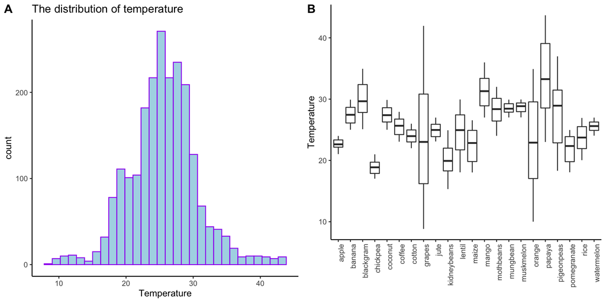

```r
p1 <- ggplot(crop_rmd) +
  geom_histogram(aes(x = temperature),
                 fill = 'lightblue', color = 'purple') +
  labs(x = 'Temperature', title = 'The distribution of temperature') +
  theme_classic()
p2 <- ggplot(crop_rmd) +
  geom_boxplot(aes(x = label, y = temperature)) +
  labs(y = 'Temperature', x = '') +
  theme_classic() +
  theme(axis.text.x = element_text(angle = 90, hjust = 1))

plot_grid(p1, p2, labels = "AUTO")
```

#### Groups and facets in `ggplot2`

Now let’s try to use groups and facets in `ggplot2`.

##### Groups

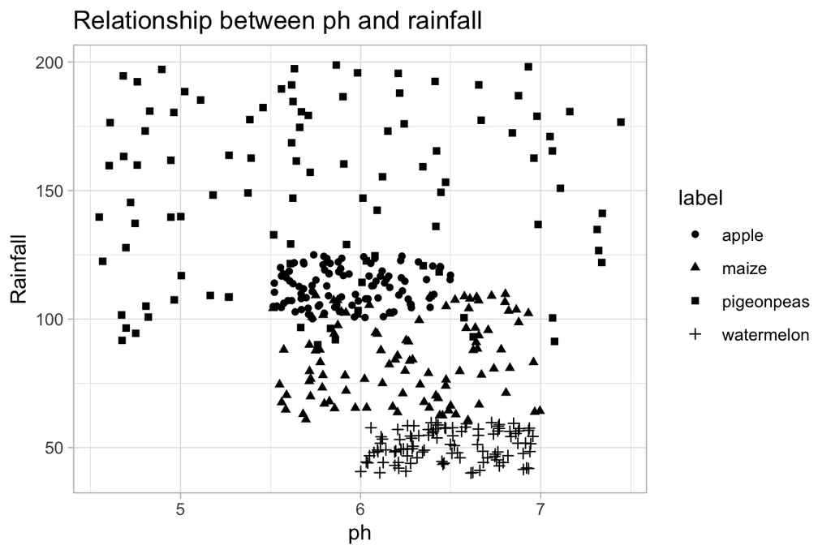

```r
# Subset the dataset
set.seed(12)
crop_rmd <- crop_rmd %>%
  filter(label %in% sample(unique(crop_rmd$label), 4))

## Groups for shape
ggplot(crop_rmd) +
  geom_point(aes(x = ph, y = rainfall,
                 shape = label)) +
  labs(x = 'ph',
       y = 'Rainfall',
       title = 'Relationship between ph and rainfall') +
  theme_light()
```

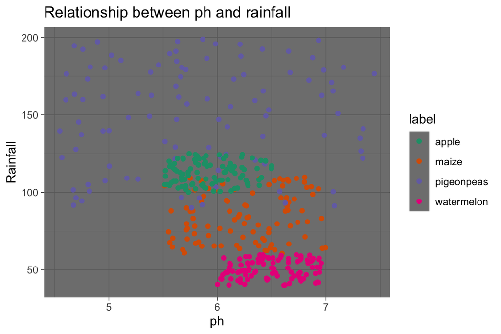

```r
## Groups for color
ggplot(crop_rmd) +
  geom_point(aes(x = ph, y = rainfall,
                 color = label)) +
  scale_color_brewer(palette = "Dark2") +
  labs(x = 'ph',
       y = 'Rainfall',
       title = 'Relationship between ph and rainfall') +
  theme_dark()
```

##### Facets

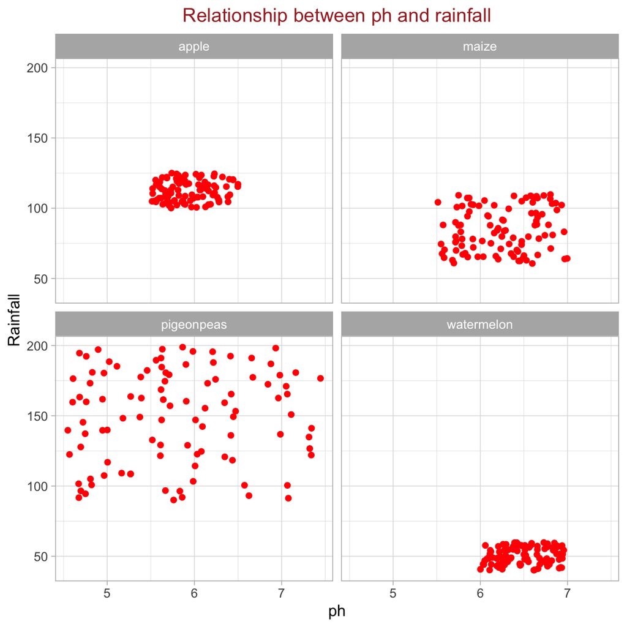

```r
ggplot(crop_rmd) +
  geom_point(aes(x = ph, y = rainfall), color = 'red') +
  facet_wrap(~ label) +
  labs(x = 'ph',
       y = 'Rainfall',
       title = 'Relationship between ph and rainfall') +
  theme_light() +
  theme(plot.title = element_text(color = "brown",
                                  hjust = 0.5))
```